# Welcome to St. Louis Crime Mapping

## Analysis and interaction crime maps in St. Louis

```python
# This Python 3 environment comes with many helpful analytics libraries installed
# It is defined by the kaggle/python docker image: https://github.com/kaggle/docker-python
# For example, here's several helpful packages to load in
import numpy as np
import pandas as pd
import folium
import matplotlib.pyplot as plt
import seaborn as sns
# magic word for producing visualizations in notebook
%matplotlib inline
```

```python
#load the data
file_name = '{}2018.CSV'
df_list = []
for i in range(1, 13):
    df_list.append(pd.read_csv(file_name.format(i)))
df = pd.concat(df_list)
```

```python
df.shape # 46742 rows, 20 columns
```

```
(46742, 20)
```

## Data preprocessing

### Deal with missing data

```python
# count the number of missing data in each columns
df.isnull().sum()
```

```
Complaint              0
CodedMonth             0
DateOccur              0
FlagCrime              0
FlagUnfounded          0
FlagAdministrative     0
Count                  0
FlagCleanup            0
Crime                  0
District               0
Description            0
ILEADSAddress          0
ILEADSStreet           0
Neighborhood           0
LocationName          31
LocationComment        2
CADAddress             0
CADStreet              0
XCoord                 0
YCoord                 0
dtype: int64
```

```python
#drop the missing data
df = df.dropna()
```

```python
df.head()
```

|  | Complaint | CodedMonth | DateOccur | FlagCrime | FlagUnfounded | FlagAdministrative | Count | FlagCleanup | Crime | District | Description | ILEADSAddress | ILEADSStreet | Neighborhood | LocationName | LocationComment | CADAddress | CADStreet | XCoord | YCoord |
| --- | --- | --- | --- | --- | --- | --- | --- | --- | --- | --- | --- | --- | --- | --- | --- | --- | --- | --- | --- | --- |
| 0 | 18-001804 | 2018-01 | 01/01/2018 00:01 | Y |  |  | 1 |  | 31111 | 1 | ROBBERY-HIGHWAY /FIREARM USED/SUCCESSFUL | 6431 | IDAHO AVE | 1 |  | ON STREET IN FRONT OF 6431 IDAHO | 6431 | IDAHO | 890047.4 | 992586.3 |
| 1 | 18-002209 | 2018-01 | 01/01/2018 00:01 | Y |  |  | 1 |  | 142320 | 5 | DESTRUCTION OF PROPERTY-MALICIOUS/PRIV PROP | 5506 | ETZEL AVE | 48 |  |  | 5506 | ETZEL | 884087.5 | 1030426.0 |
| 2 | 18-000063 | 2018-01 | 01/01/2018 00:01 | Y |  |  | 1 |  | 67601 | 4 | LARCENY-FROM BUILDING $500 - $24,999 | 2543 | N GRAND BLVD | 59 | THE BOULEVARD |  | 2543 | GRAND | 899361.5 | 1026965.0 |
| 3 | 18-000018 | 2018-01 | 01/01/2018 00:01 | Y |  |  | 1 |  | 41011 | 2 | AGG.ASSAULT-FIREARM/CITIZEN ADULT 1ST DEGREE | 4000 | DE TONTY ST | 27 |  |  | 4000 | DE TONTY | 892323.3 | 1013550.0 |
| 4 | 18-000003 | 2018-01 | 01/01/2018 00:01 | Y |  |  | 1 |  | 41011 | 3 | AGG.ASSAULT-FIREARM/CITIZEN ADULT 1ST DEGREE | 3149 | PESTALOZZI ST | 25 |  |  | 3149 | PESTALOZZI | 896039.9 | 1008823.0 |

### Drop useless columns

```python
#drop some useless columns
df = df.drop(axis = 1,labels=['Complaint', 'FlagCrime', 'FlagUnfounded',
                               'FlagAdministrative', 'Count','FlagCleanup', 'Crime'
                               ,'LocationComment','CADAddress','CADStreet','CADAddress','CADStreet'])
```

```python
df.head()
#df.shape
```

|  | CodedMonth | DateOccur | District | Description | ILEADSAddress | ILEADSStreet | Neighborhood | LocationName | XCoord | YCoord |
| --- | --- | --- | --- | --- | --- | --- | --- | --- | --- | --- |
| 0 | 2018-01 | 01/01/2018 00:01 | 1 | ROBBERY-HIGHWAY /FIREARM USED/SUCCESSFUL | 6431 | IDAHO AVE | 1 |  | 890047.4 | 992586.3 |
| 1 | 2018-01 | 01/01/2018 00:01 | 5 | DESTRUCTION OF PROPERTY-MALICIOUS/PRIV PROP | 5506 | ETZEL AVE | 48 |  | 884087.5 | 1030426.0 |
| 2 | 2018-01 | 01/01/2018 00:01 | 4 | LARCENY-FROM BUILDING $500 - $24,999 | 2543 | N GRAND BLVD | 59 | THE BOULEVARD | 899361.5 | 1026965.0 |
| 3 | 2018-01 | 01/01/2018 00:01 | 2 | AGG.ASSAULT-FIREARM/CITIZEN ADULT 1ST DEGREE | 4000 | DE TONTY ST | 27 |  | 892323.3 | 1013550.0 |
| 4 | 2018-01 | 01/01/2018 00:01 | 3 | AGG.ASSAULT-FIREARM/CITIZEN ADULT 1ST DEGREE | 3149 | PESTALOZZI ST | 25 |  | 896039.9 | 1008823.0 |

#### Here, we can see there are two columns of data, we should use the actual occur data for the data analysis, so check the difference between CodedMonth and DataOccur

```python
#extract the month and year from DateOccur to build a new column 'month_year'
df['month_year'] = pd.to_datetime(df['DateOccur']).dt.to_period('M')
```

```python
#convert month_year to string
df['month_year']=df['month_year'].astype(str)
```

```python
df.head()
```

|  | CodedMonth | DateOccur | District | Description | ILEADSAddress | ILEADSStreet | Neighborhood | LocationName | XCoord | YCoord | month_year |
| --- | --- | --- | --- | --- | --- | --- | --- | --- | --- | --- | --- |
| 0 | 2018-01 | 01/01/2018 00:01 | 1 | ROBBERY-HIGHWAY /FIREARM USED/SUCCESSFUL | 6431 | IDAHO AVE | 1 |  | 890047.4 | 992586.3 | 2018-01 |
| 1 | 2018-01 | 01/01/2018 00:01 | 5 | DESTRUCTION OF PROPERTY-MALICIOUS/PRIV PROP | 5506 | ETZEL AVE | 48 |  | 884087.5 | 1030426.0 | 2018-01 |
| 2 | 2018-01 | 01/01/2018 00:01 | 4 | LARCENY-FROM BUILDING $500 - $24,999 | 2543 | N GRAND BLVD | 59 | THE BOULEVARD | 899361.5 | 1026965.0 | 2018-01 |
| 3 | 2018-01 | 01/01/2018 00:01 | 2 | AGG.ASSAULT-FIREARM/CITIZEN ADULT 1ST DEGREE | 4000 | DE TONTY ST | 27 |  | 892323.3 | 1013550.0 | 2018-01 |
| 4 | 2018-01 | 01/01/2018 00:01 | 3 | AGG.ASSAULT-FIREARM/CITIZEN ADULT 1ST DEGREE | 3149 | PESTALOZZI ST | 25 |  | 896039.9 | 1008823.0 | 2018-01 |

```python
#compare CodedMonth and month_year
print('the number of rows that codedmonth and month_year are different :', df[(df['CodedMonth']!=df['month_year'])].shape[0])
print('the number of rows that codedmonth bigger than month_year and month_tear < 2018-01 :',df[(df['CodedMonth']>df['month_year']) & (df['month_year']<'2018-01')].shape[0])
print('the number of rows that codedmonth bigger than month_year and month_tear >= 2018-01 :',df[(df['CodedMonth']>df['month_year']) & (df['month_year']>='2018-01')].shape[0])
```

```
the number of rows that codedmonth and month_year are different : 4402
the number of rows that codedmonth bigger than month_year and month_tear < 2018-01 : 947
the number of rows that codedmonth bigger than month_year and month_tear >= 2018-01 : 3455
```

```python
new_df=df[df['month_year']>='2018-01']
```

```python
print('The actual 2018 crime data has the shape of :',new_df.shape)
```

```
The actual 2018 crime data has the shape of : (45762, 11)
```

```python
#drop CodedMonth and DateOccur and then rename the month_year
new_df.drop(axis = 1,labels=['DateOccur', 'CodedMonth'],inplace=True)
new_df.rename(columns={'month_year':'Date'}, inplace=True)
new_df.head()
```

|  | District | Description | ILEADSAddress | ILEADSStreet | Neighborhood | LocationName | XCoord | YCoord | Date |
| --- | --- | --- | --- | --- | --- | --- | --- | --- | --- |
| 0 | 1 | ROBBERY-HIGHWAY /FIREARM USED/SUCCESSFUL | 6431 | IDAHO AVE | 1 |  | 890047.4 | 992586.3 | 2018-01 |
| 1 | 5 | DESTRUCTION OF PROPERTY-MALICIOUS/PRIV PROP | 5506 | ETZEL AVE | 48 |  | 884087.5 | 1030426.0 | 2018-01 |
| 2 | 4 | LARCENY-FROM BUILDING $500 - $24,999 | 2543 | N GRAND BLVD | 59 | THE BOULEVARD | 899361.5 | 1026965.0 | 2018-01 |
| 3 | 2 | AGG.ASSAULT-FIREARM/CITIZEN ADULT 1ST DEGREE | 4000 | DE TONTY ST | 27 |  | 892323.3 | 1013550.0 | 2018-01 |
| 4 | 3 | AGG.ASSAULT-FIREARM/CITIZEN ADULT 1ST DEGREE | 3149 | PESTALOZZI ST | 25 |  | 896039.9 | 1008823.0 | 2018-01 |

### Convert address to the latitute and longitute

#### After looking into the column XCoord and YCoord, we can not map them into lat and lng.So instead, I choose the convert the address name into lat and lng by calling Geocoding API.

```python
new_df['address']=new_df["ILEADSAddress"]+" "+new_df["ILEADSStreet"]+", St.Louis"
```

```python
#list_x_y=[]
# for address in list(new_df['address']):
#     try:
#         list_x_y.append(gmaps.geocode(address)[0]['geometry']['location'])
#     except:
#         list_x_y.append("0")
new_df_2=pd.read_excel('output.xlsx')
```

```python
new_df['x_y']=new_df_2.x_y
new_df.shape
```

```
(45762, 11)
```

```python
#have a look at the new data set:
new_df.head()
```

|  | District | Description | ILEADSAddress | ILEADSStreet | Neighborhood | LocationName | XCoord | YCoord | Date | address | x_y |
| --- | --- | --- | --- | --- | --- | --- | --- | --- | --- | --- | --- |
| 0 | 1 | ROBBERY-HIGHWAY /FIREARM USED/SUCCESSFUL | 6431 | IDAHO AVE | 1 |  | 890047.4 | 992586.3 | 2018-01 | 6431 IDAHO AVE, St.Louis | {'lat': 38.559311, 'lng': -90.2557142} |
| 1 | 5 | DESTRUCTION OF PROPERTY-MALICIOUS/PRIV PROP | 5506 | ETZEL AVE | 48 |  | 884087.5 | 1030426.0 | 2018-01 | 5506 ETZEL AVE, St.Louis | {'lat': 38.6630773, 'lng': -90.2770613} |
| 2 | 4 | LARCENY-FROM BUILDING $500 - $24,999 | 2543 | N GRAND BLVD | 59 | THE BOULEVARD | 899361.5 | 1026965.0 | 2018-01 | 2543 N GRAND BLVD, St.Louis | {'lat': 38.6534841, 'lng': -90.22276029999999} |
| 3 | 2 | AGG.ASSAULT-FIREARM/CITIZEN ADULT 1ST DEGREE | 4000 | DE TONTY ST | 27 |  | 892323.3 | 1013550.0 | 2018-01 | 4000 DE TONTY ST, St.Louis | {'lat': 38.6167895, 'lng': -90.2480332} |
| 4 | 3 | AGG.ASSAULT-FIREARM/CITIZEN ADULT 1ST DEGREE | 3149 | PESTALOZZI ST | 25 |  | 896039.9 | 1008823.0 | 2018-01 | 3149 PESTALOZZI ST, St.Louis | {'lat': 38.6037623, 'lng': -90.23465139999999} |

```python
count=0
for i in range(len(new_df.x_y)):
    if new_df.x_y.iloc[i]=='0':
        count+=1
print('the number of 0 is:',count)
```

```
the number of 0 is: 10
```

#### We also need to delete the rows where the 'x_y' is set to be '0'

```python
#we also need to delete the rows where the x_y is set to be '0'
new_df.drop(new_df[new_df['x_y']=='0'].index, inplace=True)
count=0
for i in range(len(new_df.x_y)):
    if new_df.x_y.iloc[i]=='0':
        count+=1
print('After droping,the number of 0 is:',count)
```

```
After droping,the number of 0 is: 0
```

#### Here comes another problem, the data type of x_y is string

```python
#convert x_y from string to tuple
new_x_y=[]
for i in range(len(new_df)):
    a=new_df['x_y'].iloc[i]
    new_x_y.append((float(a[a.find(':')+2:a.find(',')]),float(a[a.find('-'):a.find('}')])))

new_df['x_y']=new_x_y
```

```python
new_df.head()
```

|  | District | Description | ILEADSAddress | ILEADSStreet | Neighborhood | LocationName | XCoord | YCoord | Date | address | x_y |
| --- | --- | --- | --- | --- | --- | --- | --- | --- | --- | --- | --- |
| 0 | 1 | ROBBERY-HIGHWAY /FIREARM USED/SUCCESSFUL | 6431 | IDAHO AVE | 1 |  | 890047.4 | 992586.3 | 2018-01 | 6431 IDAHO AVE, St.Louis | (38.559311, -90.2557142) |
| 1 | 5 | DESTRUCTION OF PROPERTY-MALICIOUS/PRIV PROP | 5506 | ETZEL AVE | 48 |  | 884087.5 | 1030426.0 | 2018-01 | 5506 ETZEL AVE, St.Louis | (38.6630773, -90.2770613) |
| 2 | 4 | LARCENY-FROM BUILDING $500 - $24,999 | 2543 | N GRAND BLVD | 59 | THE BOULEVARD | 899361.5 | 1026965.0 | 2018-01 | 2543 N GRAND BLVD, St.Louis | (38.6534841, -90.22276029999999) |
| 3 | 2 | AGG.ASSAULT-FIREARM/CITIZEN ADULT 1ST DEGREE | 4000 | DE TONTY ST | 27 |  | 892323.3 | 1013550.0 | 2018-01 | 4000 DE TONTY ST, St.Louis | (38.6167895, -90.2480332) |
| 4 | 3 | AGG.ASSAULT-FIREARM/CITIZEN ADULT 1ST DEGREE | 3149 | PESTALOZZI ST | 25 |  | 896039.9 | 1008823.0 | 2018-01 | 3149 PESTALOZZI ST, St.Louis | (38.6037623, -90.23465139999999) |

#### The new column of 'x_y' will be mush earier to use.

#### From now, we have finished the data preprocessing. Now start our data explanatory analysis.

## A little self explanatory data exploration from our side.

### Have a closer look at the incident locations

```python
#Mostly focussing on the top 10 value counts available to us in terms of Location
#and the Type of Crime
pd.value_counts(new_df['LocationName'])[:10]
```

```
                     38791
WALGREENS              177
SCHNUCKS               147
FAMILY DOLLAR          128
RESIDENCE              105
SHELL GAS STATION       80
TARGET                  76
BP GAS STATION          63
PHILLIPS 66             60
DOLLAR GENERAL          54
Name: LocationName, dtype: int64
```

```python
pd.value_counts(new_df['ILEADSStreet'])[:10]
```

```
S GRAND BLVD           972
GRAVOIS AVE            793
S BROADWAY             762
WASHINGTON AVE         696
N BROADWAY             515
UNION BLVD             482
N KINGSHIGHWAY BLVD    479
NATURAL BRIDGE AVE     460
S KINGSHIGHWAY BLVD    439
OLIVE ST               436
Name: ILEADSStreet, dtype: int64
```

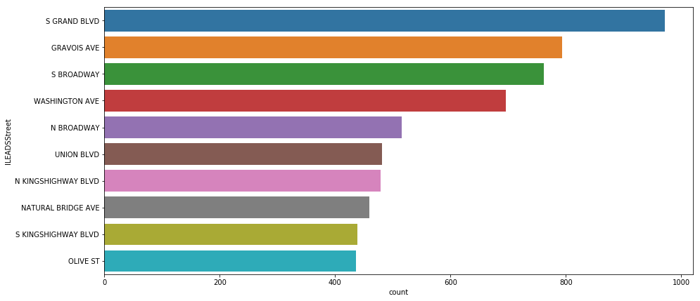

```python
plt.figure(figsize = (15, 7))
sns.countplot(y = new_df['ILEADSStreet'],order=new_df['ILEADSStreet'].value_counts().iloc[:10].index)
```

```python
#since I live in WASHINGTON AVE,I would love to have a closer look at the crime in the the ave
pd.value_counts(new_df[(new_df['ILEADSStreet']=='WASHINGTON AVE')]['Description'])[:10]
```

```
LOITERING-BEGGING                               108
LIQUOR LAWS-OTHR UNSPEC LIQ OFFNSE               51
PUBLIC ORDER-OTHR UNSPC PBLC ORDER VIOLATION     49
LARCENY-FROM BUILDING UNDER $500                 37
DESTRUCTION OF PROPERTY-MALICIOUS/PRIV PROP      36
LARCENY-FROM MTR VEH UNDER $500                  34
LARCENY-FROM MTR VEH $500 - $24,999              31
LARCENY-FROM MTR VEH UNDER $500  /ATTEMPT        27
LEAVING SCENE OF ACCIDENT                        27
LARCENY-FROM BUILDING $500 - $24,999             21
Name: Description, dtype: int64
```

#### Considering one street is very long, analysis on just one stress would be biased. We will also analyze the address, which includes the number of a street.

```python
pd.value_counts(new_df['address'])[:10]
```

```
721 N TUCKER BLVD, St.Louis                  153
3430 S GRAND BLVD, St.Louis                  147
999 N 2ND ST, St.Louis                       119
4255 HAMPTON AVE, St.Louis                   112
4101 GRAVOIS AVE, St.Louis                   110
315 N 9TH ST, St.Louis                        97
5750 NATURAL BRIDGE AVE, St.Louis             90
4949 BARNES JEWISH HOSPITAL PLZ, St.Louis     86
1915 OLIVE ST, St.Louis                       85
3431 UNION BLVD, St.Louis                     82
Name: address, dtype: int64
```

#### I would like to draw a map to better show where these locations are.

```python
#count the incident frenquency to each location
unique_locations = new_df['x_y'].value_counts()

PB_index = pd.DataFrame({"Raw_String" : unique_locations.index, "ValueCount":unique_locations})
PB_index.index = range(len(unique_locations))
#map_data=pd.concat([new_df['address'],PB_index], axis=1, join='inner')
map_data=pd.concat([new_df[['Neighborhood','address']],PB_index], axis=1, join='inner')
map_data_head=map_data[:10]
map_data.head()
```

|  | Neighborhood | address | Raw_String | ValueCount |
| --- | --- | --- | --- | --- |
| 0 | 1 | 6431 IDAHO AVE, St.Louis | (38.6429824, -90.1874462) | 214 |
| 1 | 48 | 5506 ETZEL AVE, St.Louis | (38.6270025, -90.19940419999999) | 189 |
| 2 | 59 | 2543 N GRAND BLVD, St.Louis | (38.6330069, -90.19658659999999) | 153 |
| 3 | 27 | 4000 DE TONTY ST, St.Louis | (38.5948711, -90.2424975) | 150 |
| 4 | 25 | 3149 PESTALOZZI ST, St.Louis | (38.6326828, -90.1847681) | 131 |

```python
stl_crime_street=folium.Map(location=[38.6, -90.2],
                        zoom_start=13,width=1000, height=800)
```

```python
for i in range(10):
    lat = map_data['Raw_String'].iloc[i][0]
    long = map_data['Raw_String'].iloc[i][1]
    location=map_data['address'].iloc[i]
    if map_data['ValueCount'].iloc[i] > 150:
        color = 'red'
    elif map_data['ValueCount'].iloc[i] >= 100:
        color = 'orange'
    elif map_data['ValueCount'].iloc[i] < 100:
        color = 'blue'

    popup_text = """
                Location: {}<br>
                Peace Disruptions : {}<br>"""
    popup_text = popup_text.format(
                               location,
                               map_data['ValueCount'].iloc[i]
                               )
    folium.Marker(location = [lat, long], popup= popup_text,icon=folium.Icon(color= color)).add_to(stl_crime_street)
```

```python
stl_crime_street
```

[interactive chart not shown]

#### Now from the map, we can better locate top dangerous addresses in STL. The color of marker is red when the peace disruptions are above 150. Orange between 100 to 150 and be blue when the peace distruptions below 100.

## Having a closer look at the incident types

```python
head_theft=pd.value_counts(new_df['Description'])[:10]
head_theft
```

```
LEAVING SCENE OF ACCIDENT                       5465
DESTRUCTION OF PROPERTY-MALICIOUS/PRIV PROP     3609
LARCENY-FROM MTR VEH UNDER $500                 2266
LARCENY-MTR VEH PARTS UNDER $500                1974
AUTO THEFT-PERM RETNT/UNRECOV OVER 48HR         1815
LARCENY-FROM MTR VEH $500 - $24,999             1548
SIMPLE ASSAULT-ADULT/NO INJURY                  1405
PUBLIC ORDER-OTHR UNSPC PBLC ORDER VIOLATION    1393
AGG.ASSAULT-FIREARM/CITIZEN ADULT 1ST DEGREE    1311
LARCENY-FROM BUILDING UNDER $500                1268
Name: Description, dtype: int64
```

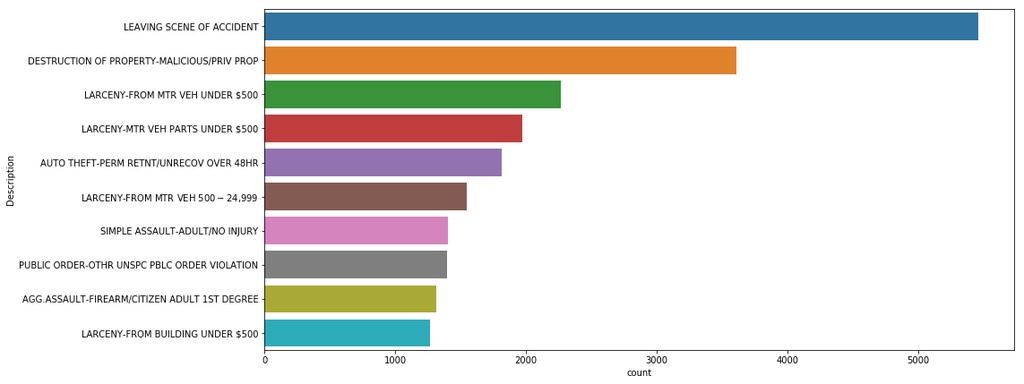

```python
plt.figure(figsize = (15, 7))
sns.countplot(y = new_df['Description'],order=new_df['Description'].value_counts().iloc[:10].index)
```

#### We can see find the countplot that, LEAVING SCENE OF ACCIDENT and DESTRUCTION OF PROPERTY-MALICIOUS/PRIV PROP are the most frequent incidents.

## Have a close look that the incident time

```python
#create a column to store month
new_df['Date'] = pd.to_datetime(new_df['Date'])
new_df['Month'] = new_df['Date'].apply(lambda x : x.month)
```

```python
#count the incidents happended in each month to the new dataframe
incidents_in_months = pd.DataFrame({"incidents" : new_df['Month'].value_counts(),
                                   'month' :new_df['Month'].value_counts().index })

incidents_in_months = incidents_in_months.sort_values(['month'], ascending=[1])
incidents_in_months.head()
```

|  | incidents | month |
| --- | --- | --- |
| 1 | 3805 | 1 |
| 2 | 3149 | 2 |
| 3 | 3630 | 3 |
| 4 | 3639 | 4 |
| 5 | 4014 | 5 |

#### Plot a picture to see the overall crime trends monthly

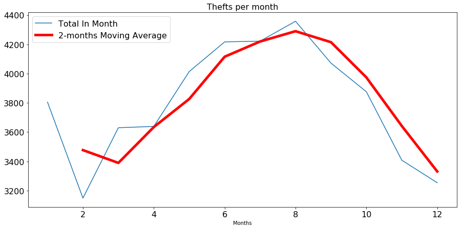

```python
plt.figure(figsize = (15,7))
plt.plot(incidents_in_months['month'],incidents_in_months['incidents'], label = 'Total In Month')
plt.plot(incidents_in_months['month'],incidents_in_months['incidents'].rolling(window = 2).mean(),color='red', linewidth=5, label='2-months Moving Average' )

plt.title('Thefts per month', fontsize=16)
plt.xlabel('Months')
plt.legend(prop={'size':16})
plt.tick_params(labelsize=16);
```

#### Here, the noticable trend is a rise in curve at the start of the year and achieveing the peak at the mid point. somehwhere at August . After that it has an equally sharp drop to the initial number of crimes as the year started.

## Prepare the map

#### I would like to firstly draw a primary scatterplot

```python
scatter_data=map_data
list_lat=[]
list_long=[]
for i in range(len(scatter_data)):
     list_lat.append(map_data.Raw_String.iloc[i][0])
     list_long.append(map_data.Raw_String.iloc[i][1])
```

```python
scatter_data['lat']=list_lat
scatter_data['long']=list_long
```

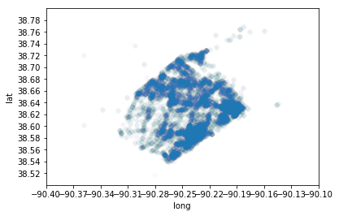

```python
sns.scatterplot(x='long',
               y='lat',
               alpha=0.007,
               data=scatter_data)
my_x_ticks = np.arange(-90.4, -90.1, 0.03)
my_y_ticks = np.arange(38.52, 38.8, 0.02)

plt.ylim((38.5, 38.8))
plt.xlim((-90.4, -90.1))
plt.yticks(my_y_ticks)
plt.xticks(my_x_ticks)
plt.figure(figsize=(20, 16))
plt.show()
```

#### We can see from the above scatterplot, most crime happened in the east STL, while the westnorth is safer.

### The top 10 dangerous Neighborhoods in STL and STL Neighborhood Maps

[figure not shown]

#### Now I want to draw a heatmap to better moniter the crime pattern in the overall STL area.

### Heatmap for overall crime analysis

```python
stl_crime_heatmap=folium.Map(location=[38.6, -90.2],tiles = "Stamen Toner",
                        zoom_start=11)
```

```python
# Add data for heatmp
# data_heatmap = data[['Lat','Long']]
# data_heatmap = data.dropna(axis=0, subset=['Lat','Long'])
from folium.plugins import HeatMap
#HeatMap(map_data.Raw_String, radius=10).add_to(stl_crime_heatmap_1,gradient={.4: 'blue', .65: 'lime', 1: 'red'})
stl_crime_heatmap.add_child(HeatMap(map_data.Raw_String, radius =10, control=False))
folium.map.LayerControl(position='topright').add_to(stl_crime_heatmap)

stl_crime_heatmap
```

[interactive chart not shown]

#### From the heatmap, we can find the east of St. Louis is more dangerous than the weat. Also, the north of St. Louis is more dangerous than the south.

### draw a bubblemap to show the crime pattern

```python
# folium.TileLayer('cartodbpositron').add_to(stl_crime_map)
```

```python
stl_crime_map=folium.Map(location=[38.64, -90.2],
                        zoom_start=10.5)
for i in range(500):
    lat = map_data['Raw_String'].iloc[i][0]
    long = map_data['Raw_String'].iloc[i][1]
    location=map_data['address'].iloc[i]
    radius = map_data['ValueCount'].iloc[i] /5

    if map_data['ValueCount'].iloc[i] > 20:
        color = "#FF4500"
    else:
        color = "#008080"

    popup_text = """Latitude : {}<br>
                Longitude : {}<br>
                Location: {}<br>
                Peace Disruptions : {}<br>"""
    popup_text = popup_text.format(lat,
                               long,
                               location,
                               map_data['ValueCount'].iloc[i]
                               )
    folium.CircleMarker(location = [lat, long], popup= popup_text,radius = radius, color = color, fill = True).add_to(stl_crime_map)
```

```python
stl_crime_map
```

[interactive chart not shown]

#### Bigger the bubble is, means this area is more dangerous. When the peace disruptions are above 20, the color of the bubble will be red.

## Conclusion

#### From the analysis, we can better judge the safety of the overall time period and the areas in STL. This analysis can be a reference for future house choosing, travel planing and crime pattern monitor in STL area.